# Micronutrient Deficiency Prediction: Multi-Country Results Report

Proxy-Only Models with Extended External Predictors — Cross-Outcome and Cross-Country Analysis

Author

Micronutrient Prediction Project

Published

April 10, 2026

# 1 Executive Summary

This report presents results from the micronutrient deficiency prediction pipeline applied across **four West and Southern African countries** — the Gambia, Ghana, Sierra Leone, and Malawi — covering up to eight outcomes per country: vitamin A deficiency (children, women), iron deficiency (children, women), folate deficiency (women), vitamin B12 deficiency (women), and zinc deficiency (children, women; Malawi only).

The pipeline uses **proxy-only predictors**: externally available data from DHS aggregate indicators, MICS, Google Earth Engine (GEE) satellite imagery, IHME disease burden estimates, MAP malaria surfaces, WFP food prices, food security (FSEC) indicators, **CHIRPS rainfall**, **WorldPop population density**, **VIIRS nighttime lights**, **SoilGrids soil properties**, **Global Data Lab (GDL) subnational development indices**, and **HarvestChoice/SPAM crop allocation data**. These represent data sources available nationally without requiring a concurrent biomarker survey. Leave-one-country-out (LOCO) cross-validation is used to assess transportability of predictions across countries.

**Proxy-only models**

All primary results use **proxy predictors only** — external data sources that are available nationally and do not require a concurrent biomarker survey. Survey-derived (`gw_`) variables are **excluded** because:

1. They cannot be used for prediction in unsurveyed areas or time periods
2. Including them produces artificially inflated AUC due to collinearity with the outcome
3. The policy-relevant question is: *how well can we predict deficiency from routinely available data?*

Uncertainty is quantified using **conformal prediction intervals** (split-conformal with adaptive width), which provide finite-sample coverage guarantees without parametric assumptions. This replaces the bootstrap approach used in earlier versions.

```r
cat(sprintf(
  "Targets loaded: %d CV, %d Admin-1, %d Admin-2 error, %d ablation, %d conformal CI, %d LOCO\n",
  n_cv, n_a1, n_a2_err, n_abl, n_boot, n_loco
))
```

```
#> Targets loaded: 23 CV, 23 Admin-1, 23 Admin-2 error, 23 ablation, 24 conformal CI, 4 LOCO
```

# 2 External Predictor Data Sources

The pipeline draws on 13+ external data sources, grouped into conceptual domains:

Table 1: External data sources used as proxy predictors. **Bold** sources are new additions to the pipeline.

| Data Source | Type | Variables | Conceptual Domains |
| --- | --- | --- | --- |
| DHS aggregate indicators | Survey | ~100–200 | Child Health, Maternal Health, Nutrition, WASH, Socioeconomic |
| MICS indicators | Survey | ~20–50 | Child Health, Education, WASH |
| Google Earth Engine (GEE) | Satellite | ~20–60 | Climate, Land Cover, Agriculture, Environment |
| IHME disease burden | Modelled | ~10–20 | Disease Burden, Child Mortality |
| MAP malaria surfaces | Modelled | ~5–10 | Malaria |
| WFP food prices | Monitoring | ~5–10 | Food Security |
| FSEC (HFID + Cadre Harmonise) | Assessment | ~5–10 | Food Security |
| **CHIRPS rainfall** | Satellite | ~15 (monthly + annual) | Climate |
| **WorldPop density** | Modelled | ~1–3 | Population, Socioeconomic |
| **VIIRS nighttime lights** | Satellite | ~1–3 | Socioeconomic, Urbanisation |
| **SoilGrids** | Modelled | ~5–10 | Agriculture, Environment |
| **GDL subnational indices** | Composite | ~5–10 | Socioeconomic, Education, Health |
| **HarvestChoice/SPAM** | Modelled | ~5–10 | Agriculture |

All variables are extracted at the Admin-2 (district) level and merged to individual survey records via spatial join. Survey-derived biomarker variables (`gw_*`) are excluded from primary models.

# 3 Descriptive Summary by Country

```r
desc_rows <- list()

for (ctry in countries) {
  ctry_label <- country_labels[ctry]

  # Admin-1 and Admin-2 counts from GADM polygons
  n_a1_units <- if (!is.null(poly_a1[[ctry]])) nrow(poly_a1[[ctry]]) else NA
  n_a2_units <- if (!is.null(poly_a2[[ctry]])) nrow(poly_a2[[ctry]]) else NA

  for (oc_name in outcomes) {
    suffix <- paste0(ctry, "_", oc_name)

    # Load outcome data to get sample sizes and predictor counts
    od <- load_target(paste0("outcome_data_", suffix))
    n_obs <- NA_integer_
    n_pred <- NA_integer_
    if (!is.null(od) && is.list(od)) {
      if (!is.null(od$data)) n_obs <- nrow(od$data)
      if (!is.null(od$Xvars)) n_pred <- length(od$Xvars)
    }

    # Get prevalence from binary diagnostics if available
    bin_diag <- load_target(paste0("diagnostics_", suffix))
    n_events <- NA_integer_
    prev_pct <- NA_character_
    if (!is.null(bin_diag) && !is.null(bin_diag$binary_metrics)) {
      n_events <- bin_diag$binary_metrics$n_events
      prev_pct <- sprintf("%.1f%%", bin_diag$binary_metrics$prevalence * 100)
    }

    desc_rows[[suffix]] <- data.frame(
      Country  = ctry_label,
      Outcome  = outcome_labels[oc_name],
      Admin1   = n_a1_units,
      Admin2   = n_a2_units,
      n        = n_obs,
      Events   = n_events,
      Prevalence = prev_pct,
      p        = n_pred,
      stringsAsFactors = FALSE
    )
  }
}

if (length(desc_rows) > 0) {
  desc_df <- do.call(rbind, desc_rows)
  rownames(desc_df) <- NULL
  desc_df <- desc_df[!is.na(desc_df$n), ]

  kable(desc_df,
        col.names = c("Country", "Outcome", "Admin-1 regions", "Admin-2 districts",
                       "Observations (n)", "Events", "Prevalence",
                       "Proxy predictors (p)"),
        caption = "Descriptive summary: geographic units, sample sizes, prevalence, and predictor dimensions by country and outcome") |>
    kable_styling(bootstrap_options = c("striped", "hover"),
                  full_width = FALSE, font_size = 11) |>
    collapse_rows(columns = 1:4, valign = "top")
} else {
  cat("No outcome data targets loaded.")
}
```

Descriptive summary: geographic units, sample sizes, prevalence, and predictor dimensions by country and outcome

|  | Country | Outcome | Admin-1 regions | Admin-2 districts | Observations (n) | Events | Prevalence | Proxy predictors (p) |
| --- | --- | --- | --- | --- | --- | --- | --- | --- |
| 1 | Gambia | Vitamin A (children) | 6 | 37 | 1020 | 266 | 26.1% | 1196 |
|  | Gambia |  |  | 37 | 1413 | 42 | 3.0% | 1196 |
|  | Gambia |  |  | 37 | 1013 | 425 | 41.9% | 1196 |
|  | Gambia |  |  | 37 | 1402 | 437 | 31.2% | 1196 |
| 9 | Ghana | Vitamin A (children) | 16 | 260 | 1165 | 240 | 20.6% | 1672 |
|  | Ghana |  |  | 260 | 992 | 13 | 1.3% | 1672 |
|  | Ghana |  |  | 260 | 1159 | 208 | 17.9% | 1672 |
|  | Ghana |  |  | 260 | 981 | 83 | 8.5% | 1672 |
|  | Ghana |  |  | 260 | 475 | 260 | 54.7% | 1672 |
|  | Ghana |  |  | 260 | 473 | 40 | 8.5% | 1672 |
| 17 | Sierra Leone | Vitamin A (children) | 4 | 14 | 486 | 89 | 18.3% | 758 |
|  | Sierra Leone |  |  | 14 | 774 | 18 | 2.3% | 758 |
|  | Sierra Leone |  |  | 14 | 486 | 28 | 5.8% | 758 |
|  | Sierra Leone |  |  | 14 | 774 | NA | NA | 758 |
|  | Sierra Leone |  |  | 14 | 766 | 608 | 79.4% | 758 |
|  | Sierra Leone |  |  | 14 | 768 | 4 | 0.5% | 758 |
| 25 | Malawi | Vitamin A (children) | 28 | 256 | 1102 | 219 | 19.9% | 933 |
|  | Malawi |  |  | 256 | 807 | 17 | 2.1% | 933 |
|  | Malawi |  |  | 256 | 1102 | 107 | 9.7% | 933 |
|  | Malawi |  |  | 256 | 752 | 74 | 9.8% | 933 |
|  | Malawi |  |  | 256 | 799 | NA | NA | 933 |
|  | Malawi |  |  | 256 | 809 | 23 | 2.8% | 933 |
|  | Malawi |  |  | 256 | 1087 | 637 | 58.6% | 933 |
|  | Malawi |  |  | 256 | 814 | 504 | 61.9% | 933 |

# 4 Cross-Validated Model Performance

## 4.1 Combined CV performance table

```r
if (!is.null(cv_perf) && nrow(cv_perf) > 0) {
  cv_display <- cv_perf |>
    mutate(
      outcome_label = outcome_labels[outcome],
      across(any_of(c("rmse", "mae", "r2", "R2", "r", "correlation",
                       "auc", "brier")), ~ round(., 3))
    )

  cv_show <- cv_display |>
    select(Country = country, Outcome = outcome_label, Model = model_type,
           any_of(c("n", "rmse", "mae", "r2", "R2", "r", "correlation",
                     "auc", "brier"))) |>
    arrange(Country, Outcome, Model)

  kable(cv_show,
        caption = "Cross-validated performance --- proxy-only models (all countries)") |>
    kable_styling(bootstrap_options = c("striped", "hover"),
                  full_width = FALSE, font_size = 11) |>
    collapse_rows(columns = 1, valign = "top")
} else {
  cat("No CV performance targets loaded.")
}
```

Cross-validated performance --- proxy-only models (all countries)

| Country | Outcome | Model | n | rmse | mae | r2 | r | auc | brier |
| --- | --- | --- | --- | --- | --- | --- | --- | --- | --- |
| Gambia | Iron deficiency (children) | binary | 1013 | NA | NA | NA | NA | 0.655 | 0.227 |
|  | Iron deficiency (children) | continuous | 1013 | 0.804 | 0.651 | 0.076 | 0.280 | NA | NA |
|  | Iron deficiency (women) | binary | 1402 | NA | NA | NA | NA | 0.663 | 0.199 |
|  | Iron deficiency (women) | continuous | 1402 | 0.882 | 0.724 | 0.089 | 0.301 | NA | NA |
|  | Vitamin A (children) | binary | 1020 | NA | NA | NA | NA | 0.676 | 0.179 |
|  | Vitamin A (children) | continuous | 1020 | 0.232 | 0.179 | 0.081 | 0.292 | NA | NA |
|  | Vitamin A (women) | binary | 1413 | NA | NA | NA | NA | 0.847 | 0.027 |
|  | Vitamin A (women) | continuous | 1413 | 0.465 | 0.306 | 0.105 | 0.326 | NA | NA |
| Ghana | Folate deficiency (women) | binary | 475 | NA | NA | NA | NA | 0.775 | 0.196 |
|  | Folate deficiency (women) | continuous | 475 | 8.356 | 6.278 | 0.200 | 0.463 | NA | NA |
|  | Iron deficiency (children) | binary | 1159 | NA | NA | NA | NA | 0.828 | 0.115 |
|  | Iron deficiency (children) | continuous | 1159 | 0.824 | 0.669 | 0.267 | 0.518 | NA | NA |
|  | Iron deficiency (women) | binary | 981 | NA | NA | NA | NA | 0.720 | 0.073 |
|  | Iron deficiency (women) | continuous | 981 | 0.759 | 0.611 | 0.154 | 0.397 | NA | NA |
|  | Vitamin A (children) | binary | 1165 | NA | NA | NA | NA | 0.672 | 0.154 |
|  | Vitamin A (children) | continuous | 1165 | 0.280 | 0.210 | 0.129 | 0.363 | NA | NA |
|  | Vitamin A (women) | binary | 992 | NA | NA | NA | NA | 0.917 | 0.012 |
|  | Vitamin A (women) | continuous | 992 | 0.547 | 0.408 | 0.153 | 0.397 | NA | NA |
|  | Vitamin B12 deficiency (women) | binary | 473 | NA | NA | NA | NA | 0.855 | 0.065 |
|  | Vitamin B12 deficiency (women) | continuous | 473 | 216.959 | 169.883 | 0.231 | 0.492 | NA | NA |
| Malawi | Folate deficiency (women) | continuous | 799 | 26.730 | 19.027 | 0.381 | 0.622 | NA | NA |
|  | Iron deficiency (children) | binary | 1102 | NA | NA | NA | NA | 0.703 | 0.083 |
|  | Iron deficiency (children) | continuous | 1102 | 20.969 | 16.028 | 0.138 | 0.380 | NA | NA |
|  | Iron deficiency (women) | binary | 752 | NA | NA | NA | NA | 0.795 | 0.077 |
|  | Iron deficiency (women) | continuous | 752 | 38.155 | 22.622 | 0.000 | NA | NA | NA |
|  | Vitamin A (children) | binary | 1102 | NA | NA | NA | NA | 0.670 | 0.150 |
|  | Vitamin A (children) | continuous | 1102 | 0.272 | 0.215 | 0.056 | 0.261 | NA | NA |
|  | Vitamin A (women) | binary | 807 | NA | NA | NA | NA | 0.929 | 0.019 |
|  | Vitamin A (women) | continuous | 807 | 0.423 | 0.325 | 0.092 | 0.314 | NA | NA |
|  | Vitamin B12 deficiency (women) | binary | 809 | NA | NA | NA | NA | 0.904 | 0.025 |
|  | Vitamin B12 deficiency (women) | continuous | 809 | 239.091 | 163.900 | 0.529 | 0.731 | NA | NA |
|  | Zinc deficiency (children) | binary | 1087 | NA | NA | NA | NA | 0.765 | 0.195 |
|  | Zinc deficiency (children) | continuous | 1087 | 21.028 | 12.170 | 0.168 | 0.412 | NA | NA |
|  | Zinc deficiency (women) | binary | 814 | NA | NA | NA | NA | 0.787 | 0.185 |
|  | Zinc deficiency (women) | continuous | 814 | 18.092 | 11.052 | 0.267 | 0.519 | NA | NA |
| Sierra Leone | Folate deficiency (women) | binary | 766 | NA | NA | NA | NA | 0.711 | 0.149 |
|  | Folate deficiency (women) | continuous | 766 | 4.698 | 2.492 | 0.138 | 0.374 | NA | NA |
|  | Iron deficiency (children) | binary | 486 | NA | NA | NA | NA | 0.767 | 0.051 |
|  | Iron deficiency (children) | continuous | 486 | 41.528 | 33.073 | 0.113 | 0.347 | NA | NA |
|  | Vitamin A (children) | binary | 486 | NA | NA | NA | NA | 0.667 | 0.142 |
|  | Vitamin A (children) | continuous | 486 | 0.354 | 0.254 | 0.033 | 0.191 | NA | NA |
|  | Vitamin A (women) | binary | 774 | NA | NA | NA | NA | 0.673 | 0.023 |
|  | Vitamin A (women) | continuous | 774 | 0.480 | 0.352 | 0.112 | 0.343 | NA | NA |
|  | Vitamin B12 deficiency (women) | binary | 768 | NA | NA | NA | NA | 0.500 | 0.005 |
|  | Vitamin B12 deficiency (women) | continuous | 768 | 239.308 | 181.374 | 0.170 | 0.417 | NA | NA |

## 4.2 Forest plots: Key metrics by outcome and country

```r
# Compute DeLong 95% CIs for ROC-AUC from CV predictions
# This uses the stored Y and yhat_full from each SL fit
auc_ci_rows <- list()
for (ctry in countries) {
  for (oc in outcomes) {
    tname <- paste0("sl_fit_", ctry, "_", oc)
    sl_obj <- load_target(tname)
    if (is.null(sl_obj) || is.null(sl_obj$bin_fit)) next
    bf <- sl_obj$bin_fit
    Y <- as.numeric(bf$res$Y)
    yhat <- as.numeric(bf$res$yhat_full)
    if (length(unique(Y)) < 2 || all(is.na(yhat))) next

    ci <- tryCatch({
      roc_obj <- pROC::roc(Y, yhat, quiet = TRUE)
      ci_obj <- pROC::ci.auc(roc_obj, method = "delong")
      data.frame(
        country  = country_labels[ctry],
        outcome  = oc,
        auc      = as.numeric(ci_obj)[2],
        auc_lo   = as.numeric(ci_obj)[1],
        auc_hi   = as.numeric(ci_obj)[3],
        stringsAsFactors = FALSE
      )
    }, error = function(e) NULL)
    if (!is.null(ci)) auc_ci_rows[[paste0(ctry, "_", oc)]] <- ci
  }
}
auc_ci <- if (length(auc_ci_rows) > 0) dplyr::bind_rows(auc_ci_rows) else NULL
```

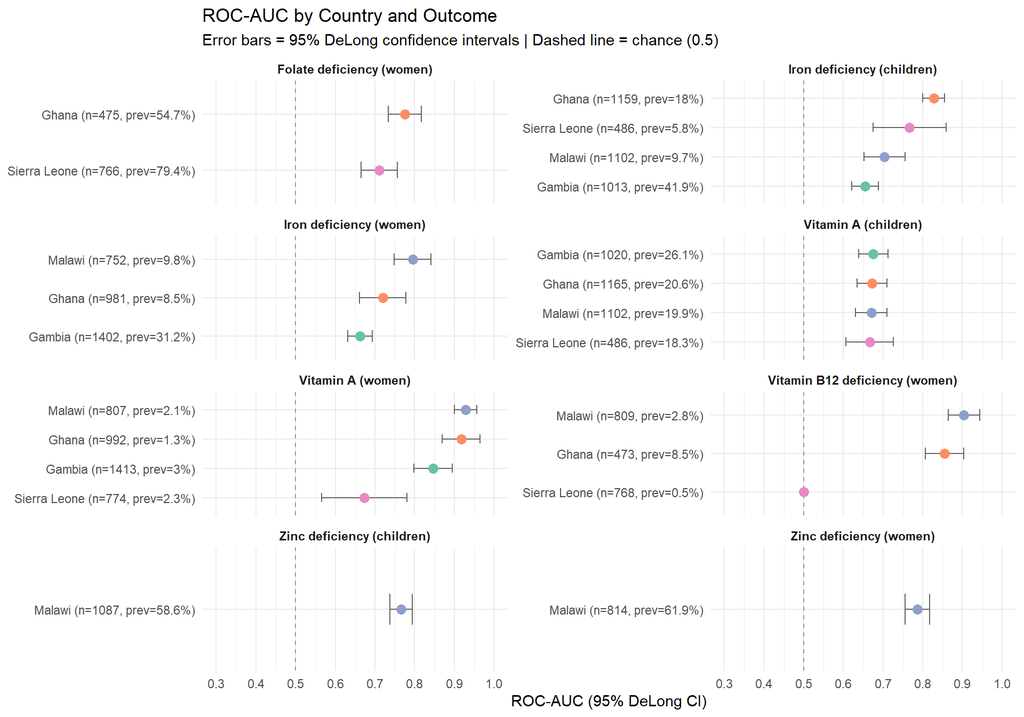

ROC-AUC with 95% DeLong CIs by outcome and country (binary models)

```r
if (!is.null(diagnostics_all) && !is.null(diagnostics_all$binary_metrics) &&
    nrow(diagnostics_all$binary_metrics) > 0) {

  bm <- diagnostics_all$binary_metrics |>
    filter(!is.na(roc_auc)) |>
    mutate(
      outcome_label = outcome_labels[outcome],
      label = paste0(country, " (n=", n, ", prev=", round(prevalence*100, 1), "%)")
    )

  # Merge DeLong CIs if available, and use DeLong AUC as the point estimate
  # so that points and intervals always come from the same (current) sl_fit
  if (!is.null(auc_ci)) {
    bm <- bm |>
      left_join(auc_ci |> select(country, outcome, auc_delong = auc, auc_lo, auc_hi),
                by = c("country", "outcome")) |>
      mutate(roc_auc = ifelse(!is.na(auc_delong), auc_delong, roc_auc)) |>
      select(-auc_delong)
  }

  if (nrow(bm) > 0) {
    p <- ggplot(bm, aes(x = roc_auc, y = reorder(label, roc_auc)))

    if ("auc_lo" %in% colnames(bm) && any(!is.na(bm$auc_lo))) {
      p <- p + geom_errorbarh(aes(xmin = auc_lo, xmax = auc_hi),
                               height = 0.3, colour = "grey40", linewidth = 0.5)
    }

    p <- p +
      geom_vline(xintercept = 0.5, linetype = "dashed", colour = "grey60") +
      geom_point(aes(colour = country), size = 3) +
      scale_x_continuous(limits = c(0.3, 1), breaks = seq(0.3, 1, 0.1)) +
      scale_colour_brewer(palette = "Set2", guide = "none") +
      facet_wrap(~ outcome_label, scales = "free_y", ncol = 2) +
      labs(x = "ROC-AUC (95% DeLong CI)", y = NULL,
           title = "ROC-AUC by Country and Outcome",
           subtitle = "Error bars = 95% DeLong confidence intervals | Dashed line = chance (0.5)") +
      theme_minimal(base_size = 11) +
      theme(strip.text = element_text(face = "bold"))

    save_fig("forest_auc", p)
    print(p)
  }
}
```

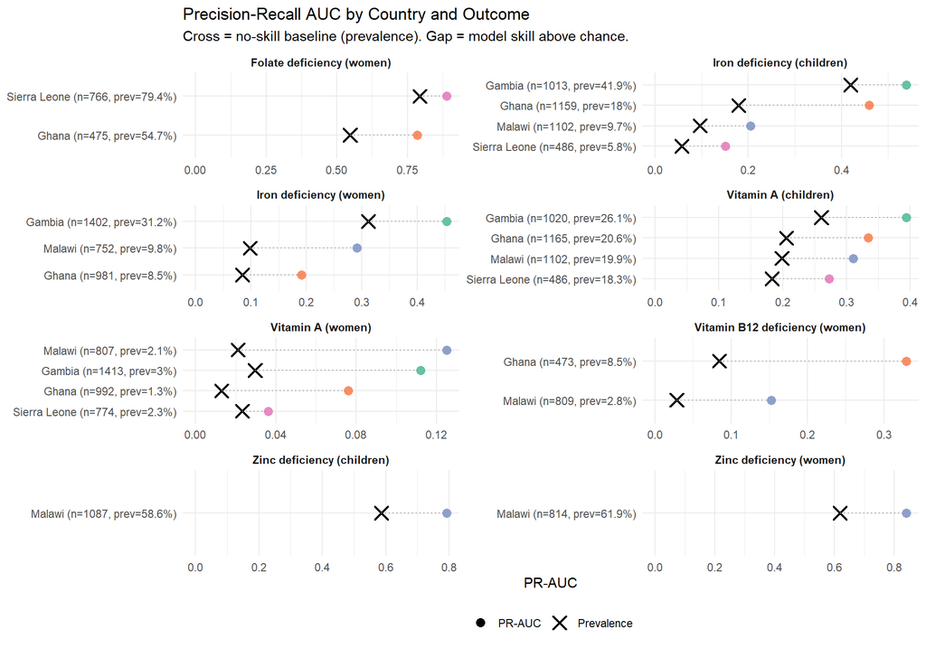

PR-AUC by outcome and country (binary models). Cross = prevalence (no-skill baseline).

```r
if (!is.null(diagnostics_all) && !is.null(diagnostics_all$binary_metrics) &&
    nrow(diagnostics_all$binary_metrics) > 0) {

  bm <- diagnostics_all$binary_metrics |>
    filter(!is.na(pr_auc)) |>
    mutate(
      outcome_label = outcome_labels[outcome],
      label = paste0(country, " (n=", n, ", prev=", round(prevalence*100, 1), "%)")
    )

  if (nrow(bm) > 0) {
    p <- ggplot(bm, aes(x = pr_auc, y = reorder(label, pr_auc))) +
      geom_point(aes(colour = country, shape = "PR-AUC"), size = 3) +
      geom_point(aes(x = prevalence, shape = "Prevalence"), size = 4, colour = "black", stroke = 1.2) +
      geom_segment(aes(x = prevalence, xend = pr_auc,
                        y = label, yend = label),
                   linetype = "dotted", colour = "grey60", linewidth = 0.4) +
      scale_shape_manual(name = NULL, values = c("PR-AUC" = 16, "Prevalence" = 4)) +
      scale_colour_brewer(palette = "Set2", guide = "none") +
      scale_x_continuous(limits = c(0, NA)) +
      facet_wrap(~ outcome_label, scales = "free", ncol = 2) +
      labs(x = "PR-AUC", y = NULL,
           title = "Precision-Recall AUC by Country and Outcome",
           subtitle = "Cross = no-skill baseline (prevalence). Gap = model skill above chance.") +
      theme_minimal(base_size = 11) +
      theme(strip.text = element_text(face = "bold"),
            legend.position = "bottom")

    save_fig("forest_prauc", p)
    print(p)
  }
}
```

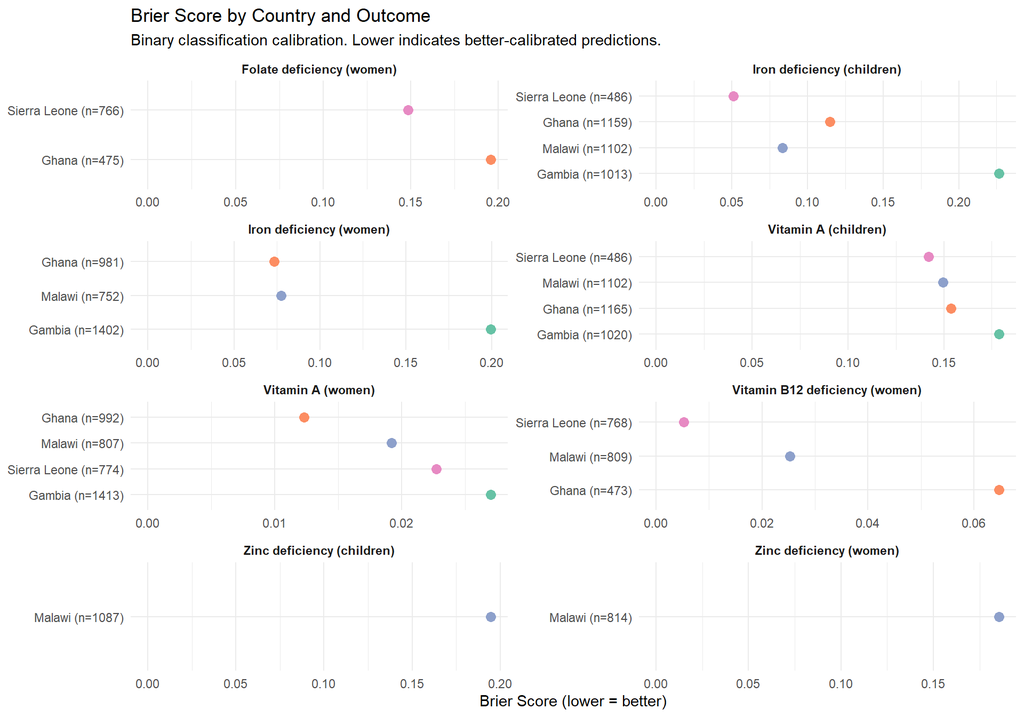

Brier score by outcome and country (binary models). Lower is better.

```r
if (!is.null(diagnostics_all) && !is.null(diagnostics_all$binary_metrics) &&
    nrow(diagnostics_all$binary_metrics) > 0) {

  bm <- diagnostics_all$binary_metrics |>
    filter(!is.na(brier)) |>
    mutate(
      outcome_label = outcome_labels[outcome],
      label = paste0(country, " (n=", n, ")")
    )

  if (nrow(bm) > 0) {
    p <- ggplot(bm, aes(x = brier, y = reorder(label, -brier))) +
      geom_point(aes(colour = country), size = 3) +
      scale_colour_brewer(palette = "Set2", guide = "none") +
      scale_x_continuous(limits = c(0, NA)) +
      facet_wrap(~ outcome_label, scales = "free", ncol = 2) +
      labs(x = "Brier Score (lower = better)", y = NULL,
           title = "Brier Score by Country and Outcome",
           subtitle = "Binary classification calibration. Lower indicates better-calibrated predictions.") +
      theme_minimal(base_size = 11) +
      theme(strip.text = element_text(face = "bold"))

    save_fig("forest_brier", p)
    print(p)
  }
}
```

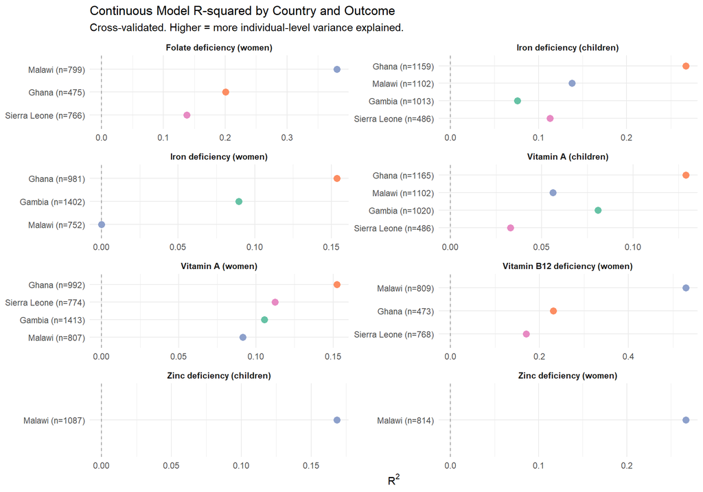

R-squared from continuous models by outcome and country.

```r
if (!is.null(diagnostics_all) && !is.null(diagnostics_all$continuous_metrics) &&
    nrow(diagnostics_all$continuous_metrics) > 0) {

  cm <- diagnostics_all$continuous_metrics |>
    filter(!is.na(r2)) |>
    mutate(
      outcome_label = outcome_labels[outcome],
      label = paste0(country, " (n=", n, ")")
    )

  if (nrow(cm) > 0) {
    p <- ggplot(cm, aes(x = r2, y = reorder(label, r2))) +
      geom_vline(xintercept = 0, linetype = "dashed", colour = "grey60") +
      geom_point(aes(colour = country), size = 3) +
      scale_colour_brewer(palette = "Set2", guide = "none") +
      facet_wrap(~ outcome_label, scales = "free", ncol = 2) +
      labs(x = expression(R^2), y = NULL,
           title = "Continuous Model R-squared by Country and Outcome",
           subtitle = "Cross-validated. Higher = more individual-level variance explained.") +
      theme_minimal(base_size = 11) +
      theme(strip.text = element_text(face = "bold"))

    save_fig("forest_r2", p)
    print(p)
  }
}
```

## 4.3 AUC comparison across countries

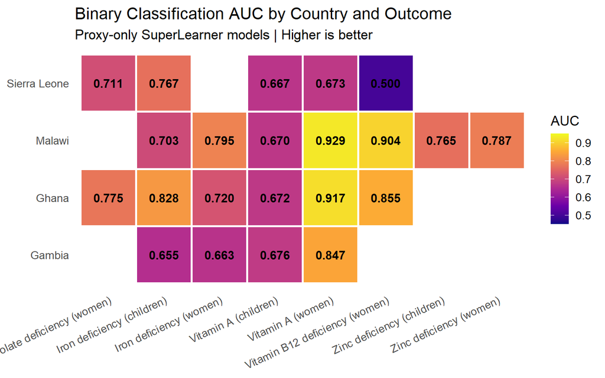

```r
# Use DeLong AUCs (from current sl_fit objects) when available,
# falling back to cv_perf targets for models without DeLong CIs
if (!is.null(auc_ci) && nrow(auc_ci) > 0) {
  cv_binary <- auc_ci |>
    filter(!is.na(auc)) |>
    mutate(outcome_label = outcome_labels[outcome])
} else if (!is.null(cv_perf) && nrow(cv_perf) > 0 && "auc" %in% colnames(cv_perf)) {
  cv_binary <- cv_perf |>
    filter(!is.na(auc)) |>
    mutate(outcome_label = outcome_labels[outcome])
} else {
  cv_binary <- NULL
}

if (!is.null(cv_binary) && nrow(cv_binary) > 0) {
  ggplot(cv_binary, aes(x = outcome_label, y = country, fill = auc)) +
    geom_tile(colour = "white", linewidth = 1) +
    geom_text(aes(label = sprintf("%.3f", auc)), size = 4, fontface = "bold") +
    scale_fill_viridis_c(name = "AUC", limits = c(0.45, 0.95), option = "plasma",
                          oob = scales::squish) +
    labs(x = NULL, y = NULL,
         title = "Binary Classification AUC by Country and Outcome",
         subtitle = "Proxy-only SuperLearner models | Higher is better") +
    theme_minimal(base_size = 13) +
    theme(axis.text.x = element_text(angle = 25, hjust = 1),
          panel.grid = element_blank())
}
```

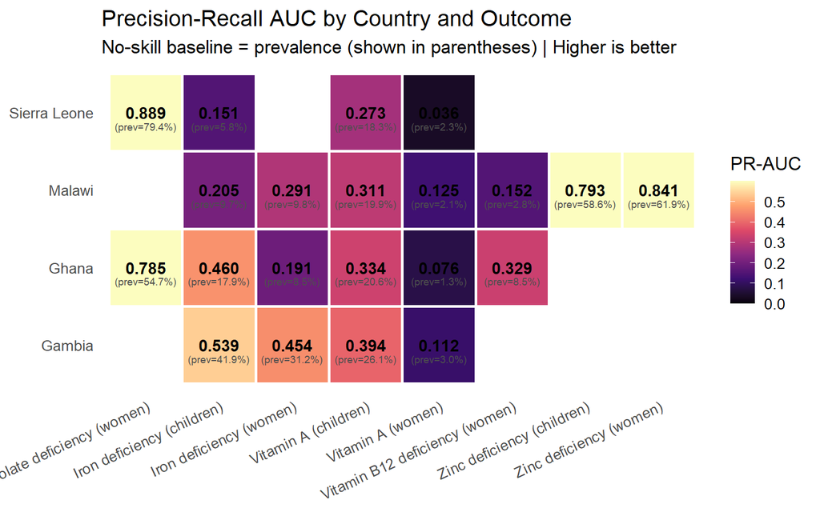

```r
if (!is.null(diagnostics_all) && !is.null(diagnostics_all$binary_metrics) &&
    nrow(diagnostics_all$binary_metrics) > 0) {
  bm_pr <- diagnostics_all$binary_metrics |>
    filter(!is.na(pr_auc)) |>
    mutate(outcome_label = outcome_labels[outcome])

  if (nrow(bm_pr) > 0) {
    p <- ggplot(bm_pr, aes(x = outcome_label, y = country, fill = pr_auc)) +
      geom_tile(colour = "white", linewidth = 1) +
      geom_text(aes(label = sprintf("%.3f", pr_auc)), size = 4, fontface = "bold") +
      # Mark prevalence (no-skill baseline) as small text below
      geom_text(aes(label = sprintf("(prev=%.1f%%)", prevalence * 100)),
                size = 2.5, vjust = 2.2, colour = "grey30") +
      scale_fill_viridis_c(name = "PR-AUC", limits = c(0, 0.6), option = "magma",
                            oob = scales::squish) +
      labs(x = NULL, y = NULL,
           title = "Precision-Recall AUC by Country and Outcome",
           subtitle = "No-skill baseline = prevalence (shown in parentheses) | Higher is better") +
      theme_minimal(base_size = 13) +
      theme(axis.text.x = element_text(angle = 25, hjust = 1),
            panel.grid = element_blank())
    save_fig("prauc_heatmap", p)
    print(p)
  }
}
```

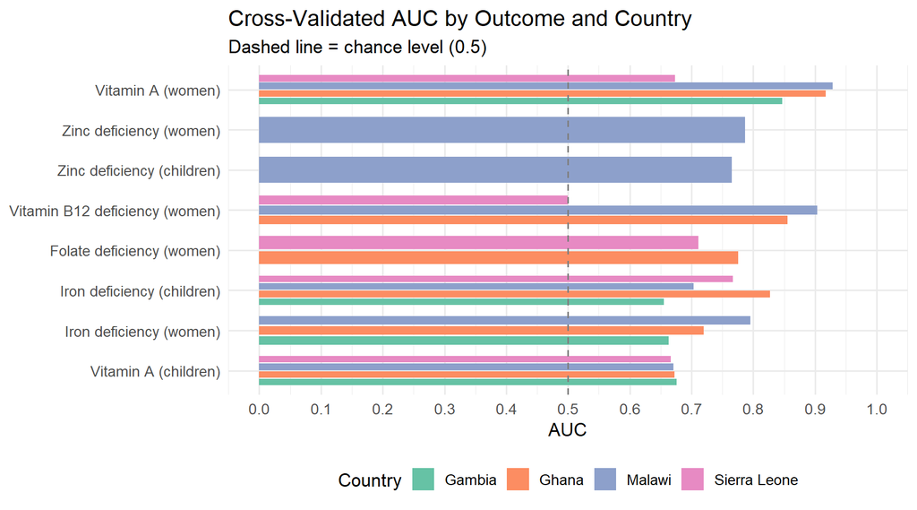

```r
if (!is.null(cv_perf) && nrow(cv_perf) > 0 && "auc" %in% colnames(cv_perf)) {
  cv_binary <- cv_perf |>
    filter(!is.na(auc)) |>
    mutate(outcome_label = outcome_labels[outcome])

  if (nrow(cv_binary) > 0) {
    ggplot(cv_binary, aes(x = reorder(outcome_label, auc), y = auc,
                           fill = country)) +
      geom_col(position = position_dodge(width = 0.75), width = 0.65) +
      geom_hline(yintercept = 0.5, linetype = "dashed", colour = "grey50") +
      scale_fill_brewer(palette = "Set2", name = "Country") +
      scale_y_continuous(limits = c(0, 1), breaks = seq(0, 1, 0.1)) +
      coord_flip() +
      labs(x = NULL, y = "AUC",
           title = "Cross-Validated AUC by Outcome and Country",
           subtitle = "Dashed line = chance level (0.5)") +
      theme(legend.position = "bottom")
  }
}
```

### 4.3.1 Interpretation

Continuous-model R-squared values are generally low, confirming that area-level proxies explain limited individual-level variance. The value of these models lies in ranking areas by relative burden, not predicting individual biomarker values.

# 5 Model Diagnostics: Beyond AUC

## 5.1 How to interpret each metric

The diagnostics table below reports several complementary metrics. No single metric tells the full story — together they reveal whether a model is useful for subnational prevalence estimation.

### 5.1.1 Discrimination metrics

**ROC-AUC (Area Under the ROC Curve)** measures whether the model can rank individuals by deficiency risk — i.e., do individuals who are truly deficient receive higher predicted probabilities than those who are not?

- **Range:** 0 to 1. A value of 0.5 means the model ranks no better than random; 1.0 means perfect ranking.
- **Interpretation:** AUC = 0.75 means that if you pick one deficient and one non-deficient individual at random, the model assigns a higher probability to the deficient individual 75% of the time.
- **Limitation:** AUC can be misleadingly high with rare outcomes (< 5% prevalence) because even a model that predicts everyone as “low risk” achieves high specificity. With fewer than ~30 events, AUC estimates have wide confidence intervals and should be interpreted cautiously.

**PR-AUC (Area Under the Precision-Recall Curve)** is a discrimination metric that focuses specifically on how well the model identifies the **deficient minority class**.

- **Baseline:** Unlike ROC-AUC (baseline = 0.5), the PR-AUC baseline equals the **prevalence**. A model that predicts the overall prevalence for everyone achieves PR-AUC = prevalence.
- **Interpretation:** PR-AUC = 0.30 with prevalence = 0.05 means the model is 6x better than random at identifying deficient individuals. PR-AUC = 0.10 with prevalence = 0.10 means the model adds nothing beyond guessing.
- **How to read it:** Divide PR-AUC by prevalence to get the “lift” — how many times better than random the model is at finding positive cases. A lift of 2–3x is useful for screening; 5x+ is strong.
- **When to use:** PR-AUC is more informative than ROC-AUC when prevalence is below ~20%, which is the case for most micronutrient outcomes in this analysis.

### 5.1.2 Calibration metrics

**Brier Score** measures the mean squared difference between predicted probabilities and actual binary outcomes (0 or 1).

- **Range:** 0 (perfect) to 1 (worst). A model predicting the overall prevalence for everyone achieves Brier = prevalence × (1 − prevalence).
- **Interpretation:** Lower is better. Brier captures both discrimination *and* calibration in a single number — a model can have good AUC but poor Brier if its predicted probabilities are systematically too high or too low.

**Brier Skill Score** compares the model’s Brier score to the null model (always predicting the prevalence).

- **Formula:** 1 − (Brier_model / Brier_null). Positive = better than the null; 0 = no improvement; negative = worse than always predicting the prevalence.
- **Interpretation:** Brier Skill = 0.15 means a 15% improvement in squared-error loss over the null model. For rare outcomes, even small positive values indicate the model adds value beyond the base rate.

**Calibration Intercept** measures systematic bias in predicted probabilities.

- **Ideal value:** 0. Positive intercept = model under-predicts on average; negative = over-predicts.
- **Interpretation:** A calibration intercept of −0.02 means predicted probabilities are, on average, 2 percentage points too high.

**Calibration Slope** measures whether the model’s predicted probabilities are appropriately spread.

- **Ideal value:** 1. Slope < 1 = predictions are over-confident (too extreme); slope > 1 = under-confident (too compressed toward the mean).
- **Interpretation:** A slope of 0.8 means the model’s risk estimates are 20% more extreme than they should be — a predicted 30% risk is actually closer to 24%, and a predicted 5% risk is actually closer to 6%.

### 5.1.3 Which metric matters most for this project?

For **subnational prevalence mapping**, the priority ordering is:

1. **Calibration** (slope ≈ 1, intercept ≈ 0) — ensures predicted probabilities can be averaged to recover area-level prevalence
2. **Brier Skill Score** > 0 — confirms the model improves over the null
3. **PR-AUC** > prevalence — confirms the model identifies high-risk areas
4. **ROC-AUC** > 0.5 — general discrimination sanity check

A model with AUC = 0.65 but calibration slope = 1.0 is **more useful for mapping** than a model with AUC = 0.80 but calibration slope = 0.5, because the latter’s area-level prevalence estimates will be biased.

## 5.2 Extended diagnostics summary table

```r
if (!is.null(diagnostics_all) && !is.null(diagnostics_all$binary_metrics) &&
    nrow(diagnostics_all$binary_metrics) > 0) {
  diag_show <- diagnostics_all$binary_metrics |>
    mutate(
      outcome_label = outcome_labels[outcome],
      across(where(is.numeric), ~ round(., 3))
    ) |>
    select(country, outcome_label, n, n_events, prevalence,
           roc_auc, pr_auc, brier, brier_skill, calib_int, calib_slope) |>
    arrange(desc(roc_auc))

  kable(diag_show,
        col.names = c("Country", "Outcome", "n", "Events", "Prevalence",
                       "ROC-AUC", "PR-AUC", "Brier", "Brier Skill", "Cal. Int.", "Cal. Slope"),
        caption = "Extended binary model diagnostics (from cross-validated predictions)") |>
    kable_styling(bootstrap_options = c("striped", "hover"),
                  full_width = FALSE, font_size = 11) |>
    column_spec(6, bold = TRUE) |>
    column_spec(7, bold = TRUE)
} else {
  cat("Diagnostics targets not yet available. Run `targets::tar_make_future(workers = 4)`.")
}
```

Extended binary model diagnostics (from cross-validated predictions)

|  | Country | Outcome | n | Events | Prevalence | ROC-AUC | PR-AUC | Brier | Brier Skill | Cal. Int. | Cal. Slope |
| --- | --- | --- | --- | --- | --- | --- | --- | --- | --- | --- | --- |
| (Intercept)...1 | Malawi | Vitamin A (women) | 807 | 17 | 0.021 | 0.929 | 0.125 | 0.019 | 0.068 | 4.104 | 2.381 |
| (Intercept)...2 | Ghana | Vitamin A (women) | 992 | 13 | 0.013 | 0.917 | 0.076 | 0.012 | 0.049 | 3.852 | 2.118 |
| (Intercept)...3 | Malawi | Vitamin B12 deficiency (women) | 809 | 23 | 0.028 | 0.904 | 0.152 | 0.025 | 0.083 | 2.548 | 1.953 |
| (Intercept)...4 | Ghana | Vitamin B12 deficiency (women) | 473 | 40 | 0.085 | 0.855 | 0.329 | 0.065 | 0.164 | 0.927 | 1.496 |
| (Intercept)...5 | Gambia | Vitamin A (women) | 1413 | 42 | 0.030 | 0.847 | 0.112 | 0.027 | 0.062 | 0.923 | 1.335 |
| (Intercept)...6 | Ghana | Iron deficiency (children) | 1159 | 208 | 0.180 | 0.828 | 0.460 | 0.115 | 0.221 | 0.205 | 1.181 |
| (Intercept)...7 | Malawi | Iron deficiency (women) | 752 | 74 | 0.098 | 0.795 | 0.291 | 0.077 | 0.129 | 0.644 | 1.335 |
| (Intercept)...8 | Malawi | Zinc deficiency (women) | 814 | 504 | 0.619 | 0.786 | 0.841 | 0.185 | 0.214 | -0.218 | 1.579 |
| (Intercept)...9 | Ghana | Folate deficiency (women) | 475 | 260 | 0.547 | 0.775 | 0.785 | 0.196 | 0.210 | -0.128 | 1.703 |
| (Intercept)...10 | Sierra Leone | Iron deficiency (children) | 486 | 28 | 0.058 | 0.767 | 0.151 | 0.051 | 0.056 | 1.498 | 1.588 |
| (Intercept)...11 | Malawi | Zinc deficiency (children) | 1087 | 637 | 0.586 | 0.765 | 0.793 | 0.195 | 0.197 | -0.166 | 1.535 |
| (Intercept)...12 | Ghana | Iron deficiency (women) | 981 | 83 | 0.085 | 0.720 | 0.191 | 0.073 | 0.053 | 0.961 | 1.508 |
| (Intercept)...13 | Sierra Leone | Folate deficiency (women) | 766 | 608 | 0.794 | 0.711 | 0.889 | 0.149 | 0.092 | -0.486 | 1.396 |
| (Intercept)...14 | Malawi | Iron deficiency (children) | 1102 | 107 | 0.097 | 0.704 | 0.205 | 0.083 | 0.049 | 1.153 | 1.546 |
| (Intercept)...15 | Gambia | Vitamin A (children) | 1020 | 266 | 0.261 | 0.676 | 0.394 | 0.179 | 0.073 | 0.212 | 1.220 |
| (Intercept)...16 | Sierra Leone | Vitamin A (women) | 774 | 18 | 0.023 | 0.673 | 0.036 | 0.023 | 0.001 | 60.316 | 17.212 |
| (Intercept)...17 | Ghana | Vitamin A (children) | 1165 | 240 | 0.206 | 0.672 | 0.334 | 0.154 | 0.060 | 0.392 | 1.306 |
| (Intercept)...18 | Malawi | Vitamin A (children) | 1102 | 219 | 0.199 | 0.670 | 0.311 | 0.150 | 0.061 | 0.639 | 1.481 |
| (Intercept)...19 | Sierra Leone | Vitamin A (children) | 486 | 89 | 0.183 | 0.667 | 0.273 | 0.142 | 0.050 | 0.430 | 1.307 |
| (Intercept)...20 | Gambia | Iron deficiency (women) | 1402 | 437 | 0.312 | 0.663 | 0.454 | 0.199 | 0.071 | 0.138 | 1.186 |
| (Intercept)...21 | Gambia | Iron deficiency (children) | 1013 | 425 | 0.420 | 0.655 | 0.539 | 0.226 | 0.070 | 0.075 | 1.261 |
| (Intercept)...22 | Sierra Leone | Vitamin B12 deficiency (women) | 768 | 4 | 0.005 | 0.500 | NA | 0.005 | 0.000 | -5.252 | NA |

**Reading this table:**

- **PR-AUC** > prevalence indicates the model has skill beyond always predicting the base rate
- **Brier Skill Score** > 0 means the model outperforms a prevalence-only baseline; negative values mean it does worse
- **Calibration slope** near 1.0 = well-calibrated; < 1 = overconfident predictions; > 1 = underconfident
- **Calibration intercept** near 0 = no systematic bias

## 5.3 Ensemble learner weights

Which learners contribute most to the SuperLearner ensemble? The metalearner (NNLS) assigns non-negative weights to each base learner, with weights summing to 1. Higher weights indicate greater contribution to the final prediction.

```r
wt_rows <- list()

for (ctry in countries) {
  for (oc_name in outcomes) {
    suffix <- paste0(ctry, "_", oc_name)
    sl <- load_target(paste0("sl_fit_", suffix))
    if (is.null(sl)) next

    for (mtype in c("cont_fit", "bin_fit")) {
      fit <- sl[[mtype]]
      if (is.null(fit) || is.null(fit$cv_risk_w_sl_revere)) next

      risk_tbl <- fit$cv_risk_w_sl_revere
      if (is.null(risk_tbl) || !is.data.frame(risk_tbl) ||
          nrow(risk_tbl) == 0 || !"coefficients" %in% colnames(risk_tbl)) next

      wt_rows[[paste0(suffix, "_", mtype)]] <- data.frame(
        country    = country_labels[ctry],
        outcome    = outcome_labels[oc_name],
        model_type = ifelse(mtype == "bin_fit", "Binary", "Continuous"),
        learner    = risk_tbl$learner,
        weight     = round(as.numeric(risk_tbl$coefficients), 3),
        stringsAsFactors = FALSE
      )
    }
  }
}

if (length(wt_rows) > 0) {
  wt_df <- do.call(rbind, wt_rows)
  rownames(wt_df) <- NULL

  # Filter to binary models and non-zero weights for the heatmap
  wt_bin <- wt_df |>
    filter(model_type == "Binary", weight > 0.001)

  if (nrow(wt_bin) > 0) {
    wt_bin$label <- paste0(wt_bin$country, " - ", wt_bin$outcome)

    ggplot(wt_bin, aes(x = learner, y = label, fill = weight)) +
      geom_tile(colour = "white", linewidth = 0.3) +
      geom_text(aes(label = ifelse(weight >= 0.01, sprintf("%.2f", weight), "")),
                size = 2.5) +
      scale_fill_gradient(low = "white", high = "#2166ac",
                          limits = c(0, 1), name = "Weight") +
      labs(
        title = "SuperLearner ensemble weights (binary models)",
        subtitle = "NNLS metalearner weights. Only learners with weight > 0 shown.",
        x = "Base learner",
        y = NULL
      ) +
      theme_minimal(base_size = 10) +
      theme(axis.text.x = element_text(angle = 45, hjust = 1))
  }
} else {
  cat("Learner weights not available — mlr3superlearner does not expose per-learner weights in the current version. The ensemble uses NNLS (non-negative least squares) metalearning to combine base learner predictions.")
}
```

```
#> Learner weights not available — mlr3superlearner does not expose per-learner weights in the current version. The ensemble uses NNLS (non-negative least squares) metalearning to combine base learner predictions.
```

## 5.4 Reliability (calibration) plots

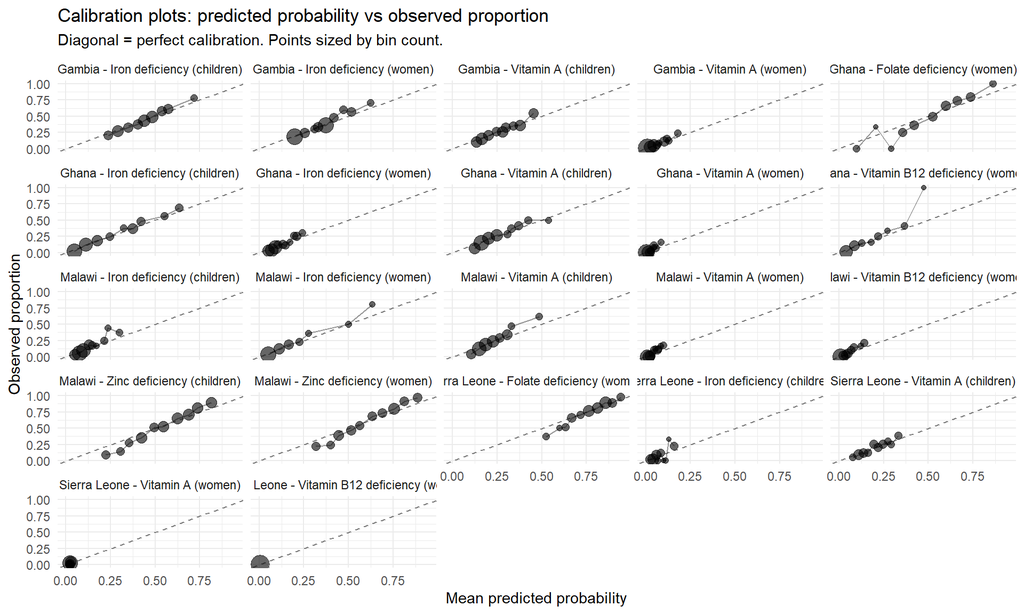

```r
if (!is.null(diagnostics_all) && !is.null(diagnostics_all$calibration_tables) &&
    nrow(diagnostics_all$calibration_tables) > 0) {

  cal <- diagnostics_all$calibration_tables |>
    filter(!is.na(mean_pred) & !is.na(mean_obs)) |>
    mutate(label = paste0(country, " - ", outcome_labels[outcome]))

  if (nrow(cal) > 0) {
    ggplot(cal, aes(x = mean_pred, y = mean_obs)) +
      geom_abline(slope = 1, intercept = 0, linetype = "dashed", colour = "grey50") +
      geom_point(aes(size = n), alpha = 0.6) +
      geom_line(alpha = 0.4) +
      facet_wrap(~ label) +
      scale_size_continuous(range = c(1.5, 6), guide = "none") +
      scale_x_continuous(limits = c(0, NA)) +
      scale_y_continuous(limits = c(0, NA)) +
      labs(
        title = "Calibration plots: predicted probability vs observed proportion",
        subtitle = "Diagonal = perfect calibration. Points sized by bin count.",
        x = "Mean predicted probability",
        y = "Observed proportion"
      ) +
      theme_minimal(base_size = 11)
  }
} else {
  cat("No calibration data available.")
}
```

## 5.5 Precision-Recall curves

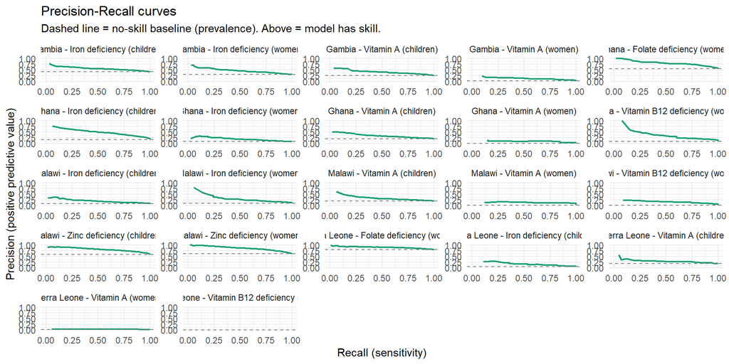

```r
if (!is.null(diagnostics_all) && !is.null(diagnostics_all$pr_curves) &&
    nrow(diagnostics_all$pr_curves) > 0) {

  pr <- diagnostics_all$pr_curves |>
    filter(!is.na(recall) & !is.na(precision)) |>
    mutate(label = paste0(country, " - ", outcome_labels[outcome]))

  # Get prevalence for no-skill lines
  prev_df <- NULL
  if (!is.null(diagnostics_all$binary_metrics) && nrow(diagnostics_all$binary_metrics) > 0) {
    prev_df <- diagnostics_all$binary_metrics |>
      mutate(label = paste0(country, " - ", outcome_labels[outcome])) |>
      select(label, prevalence)
  }

  if (nrow(pr) > 0) {
    p <- ggplot(pr, aes(x = recall, y = precision)) +
      geom_line(colour = "#1b9e77", linewidth = 0.8) +
      facet_wrap(~ label, scales = "free") +
      labs(
        title = "Precision-Recall curves",
        subtitle = "Dashed line = no-skill baseline (prevalence). Above = model has skill.",
        x = "Recall (sensitivity)",
        y = "Precision (positive predictive value)"
      ) +
      coord_cartesian(xlim = c(0, 1), ylim = c(0, 1)) +
      theme_minimal(base_size = 11)

    # Add no-skill lines per facet
    if (!is.null(prev_df)) {
      p <- p + geom_hline(data = prev_df, aes(yintercept = prevalence),
                          linetype = "dashed", colour = "grey50")
    }
    p
  }
} else {
  cat("No PR curve data available.")
}
```

## 5.6 ROC curves

Receiver Operating Characteristic curves showing the trade-off between true positive rate (sensitivity) and false positive rate (1 - specificity) at all classification thresholds.

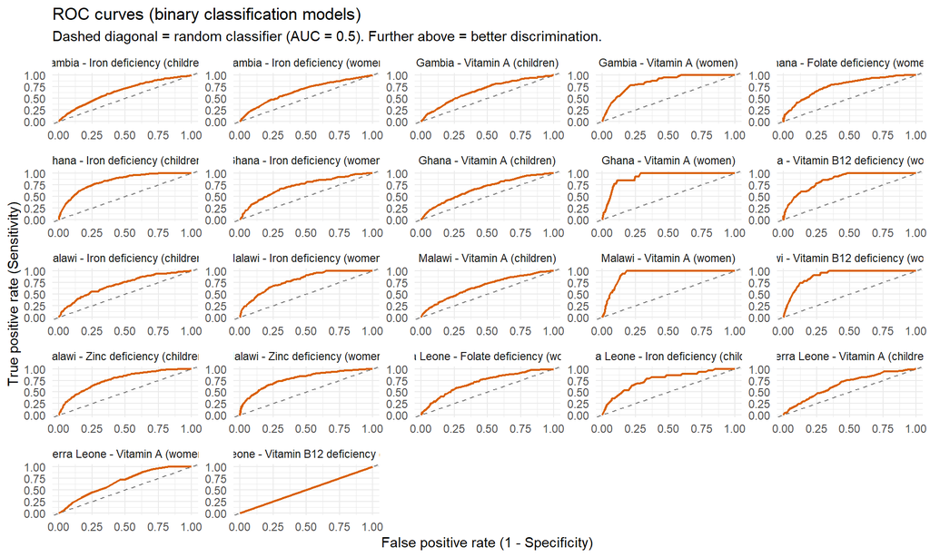

```r
if (!is.null(diagnostics_all) && !is.null(diagnostics_all$roc_curves) &&
    nrow(diagnostics_all$roc_curves) > 0) {

  roc <- diagnostics_all$roc_curves |>
    filter(!is.na(fpr) & !is.na(tpr)) |>
    mutate(label = paste0(country, " - ", outcome_labels[outcome]))

  if (nrow(roc) > 0) {
    ggplot(roc, aes(x = fpr, y = tpr)) +
      geom_abline(slope = 1, intercept = 0, linetype = "dashed", colour = "grey50") +
      geom_line(colour = "#d95f02", linewidth = 0.8) +
      facet_wrap(~ label, scales = "free") +
      labs(
        title = "ROC curves (binary classification models)",
        subtitle = "Dashed diagonal = random classifier (AUC = 0.5). Further above = better discrimination.",
        x = "False positive rate (1 - Specificity)",
        y = "True positive rate (Sensitivity)"
      ) +
      coord_cartesian(xlim = c(0, 1), ylim = c(0, 1)) +
      theme_minimal(base_size = 11)
  }
} else {
  cat("No ROC curve data available.")
}
```

## 5.7 Continuous model diagnostics

```r
if (!is.null(diagnostics_all) && !is.null(diagnostics_all$continuous_metrics) &&
    nrow(diagnostics_all$continuous_metrics) > 0) {
  cont_show <- diagnostics_all$continuous_metrics |>
    mutate(
      outcome_label = outcome_labels[outcome],
      across(where(is.numeric), ~ round(., 4))
    ) |>
    arrange(desc(r2))

  cols_to_show <- intersect(
    c("country", "outcome_label", "n", "rmse", "mae", "r2", "r",
      "prev_obs", "prev_pred", "prev_bias"),
    colnames(cont_show)
  )
  cont_show <- cont_show[, cols_to_show]

  nice_names <- c(country = "Country", outcome_label = "Outcome", n = "n",
                  rmse = "RMSE", mae = "MAE", r2 = "R2", r = "r",
                  prev_obs = "Obs. Prev.", prev_pred = "Pred. Prev.", prev_bias = "Bias")

  kable(cont_show,
        col.names = nice_names[cols_to_show],
        caption = "Continuous model diagnostics with prevalence recovery") |>
    kable_styling(bootstrap_options = c("striped", "hover"),
                  full_width = FALSE, font_size = 11)
} else {
  cat("No continuous diagnostics available.")
}
```

Continuous model diagnostics with prevalence recovery

| Country | Outcome | n | RMSE | MAE | R2 | r | Obs. Prev. | Pred. Prev. | Bias |
| --- | --- | --- | --- | --- | --- | --- | --- | --- | --- |
| Malawi | Vitamin B12 deficiency (women) | 809 | 239.0908 | 163.9003 | 0.5285 | 0.7308 | 0.9716 | 1.0000 | 0.0284 |
| Malawi | Folate deficiency (women) | 799 | 26.7304 | 19.0269 | 0.3807 | 0.6220 | 1.0000 | 1.0000 | 0.0000 |
| Ghana | Iron deficiency (children) | 1159 | 0.8237 | 0.6688 | 0.2671 | 0.5183 | 0.8119 | 0.9638 | 0.1519 |
| Malawi | Zinc deficiency (women) | 814 | 18.0920 | 11.0517 | 0.2668 | 0.5187 | 0.2555 | 0.2912 | 0.0357 |
| Ghana | Vitamin B12 deficiency (women) | 473 | 216.9594 | 169.8828 | 0.2312 | 0.4922 | 0.9175 | 1.0000 | 0.0825 |
| Ghana | Folate deficiency (women) | 475 | 8.3559 | 6.2781 | 0.2003 | 0.4626 | 0.4526 | 0.7495 | 0.2969 |
| Sierra Leone | Vitamin B12 deficiency (women) | 768 | 239.3081 | 181.3744 | 0.1703 | 0.4173 | 0.9961 | 1.0000 | 0.0039 |
| Malawi | Zinc deficiency (children) | 1087 | 21.0276 | 12.1701 | 0.1685 | 0.4125 | 0.3275 | 0.2824 | -0.0451 |
| Ghana | Iron deficiency (women) | 981 | 0.7587 | 0.6112 | 0.1537 | 0.3972 | 0.8705 | 1.0000 | 0.1295 |
| Ghana | Vitamin A (women) | 992 | 0.5468 | 0.4079 | 0.1525 | 0.3968 | 0.9869 | 1.0000 | 0.0131 |
| Malawi | Iron deficiency (children) | 1102 | 20.9693 | 16.0277 | 0.1380 | 0.3797 | 0.7985 | 1.0000 | 0.2015 |
| Sierra Leone | Folate deficiency (women) | 766 | 4.6979 | 2.4918 | 0.1378 | 0.3742 | 0.2063 | 0.0875 | -0.1188 |
| Ghana | Vitamin A (children) | 1165 | 0.2805 | 0.2096 | 0.1289 | 0.3634 | 0.7940 | 0.9914 | 0.1974 |
| Sierra Leone | Iron deficiency (children) | 486 | 41.5281 | 33.0731 | 0.1130 | 0.3467 | 0.9424 | 1.0000 | 0.0576 |
| Sierra Leone | Vitamin A (women) | 774 | 0.4795 | 0.3521 | 0.1124 | 0.3430 | 0.9767 | 1.0000 | 0.0233 |
| Gambia | Vitamin A (women) | 1413 | 0.4651 | 0.3064 | 0.1054 | 0.3259 | 0.9703 | 1.0000 | 0.0297 |
| Malawi | Vitamin A (women) | 807 | 0.4233 | 0.3254 | 0.0916 | 0.3144 | 0.9789 | 1.0000 | 0.0211 |
| Gambia | Iron deficiency (women) | 1402 | 0.8815 | 0.7236 | 0.0895 | 0.3014 | 0.5485 | 0.6127 | 0.0642 |
| Gambia | Vitamin A (children) | 1020 | 0.2323 | 0.1791 | 0.0809 | 0.2923 | 0.7392 | 1.0000 | 0.2608 |
| Gambia | Iron deficiency (children) | 1013 | 0.8040 | 0.6508 | 0.0762 | 0.2802 | 0.3771 | 0.1718 | -0.2053 |
| Malawi | Vitamin A (children) | 1102 | 0.2716 | 0.2154 | 0.0561 | 0.2612 | 0.7613 | 1.0000 | 0.2387 |
| Sierra Leone | Vitamin A (children) | 486 | 0.3543 | 0.2542 | 0.0328 | 0.1910 | 0.8169 | 1.0000 | 0.1831 |
| Malawi | Iron deficiency (women) | 752 | 38.1547 | 22.6219 | 0.0000 | NA | 0.8258 | 1.0000 | 0.1742 |

## 5.8 Stronger vs. weaker model examples

```r
if (!is.null(diagnostics_all) && !is.null(diagnostics_all$binary_metrics) &&
    nrow(diagnostics_all$binary_metrics) > 0) {
  bm <- diagnostics_all$binary_metrics |>
    filter(!is.na(roc_auc)) |>
    arrange(desc(roc_auc))

  if (nrow(bm) >= 2) {
    best  <- bm[1, ]
    worst <- bm[nrow(bm), ]

    cat(sprintf(
      "**Strongest model: %s --- %s**\n\n",
      best$country, outcome_labels[best$outcome]))
    cat(sprintf(
      "- ROC-AUC = %.3f, PR-AUC = %.3f (baseline prevalence = %.1f%%)\n",
      best$roc_auc, best$pr_auc, best$prevalence * 100))
    cat(sprintf(
      "- Brier skill = %.3f, Calibration slope = %.2f\n",
      best$brier_skill, best$calib_slope))
    cat("- This model shows meaningful discrimination above chance and ",
        "reasonable calibration, suggesting area-level prevalence estimates ",
        "from this model are informative.\n\n")

    cat(sprintf(
      "**Weakest model: %s --- %s**\n\n",
      worst$country, outcome_labels[worst$outcome]))
    cat(sprintf(
      "- ROC-AUC = %.3f, PR-AUC = %.3f (baseline prevalence = %.1f%%)\n",
      worst$roc_auc, worst$pr_auc, worst$prevalence * 100))
    cat(sprintf(
      "- Brier skill = %.3f, Calibration slope = %.2f\n",
      worst$brier_skill, worst$calib_slope))
    if (worst$roc_auc <= 0.55) {
      cat("- This model shows near-chance discrimination. Area-level estimates ",
          "from this model should be interpreted with extreme caution and ",
          "validated against any available survey data.\n\n")
    } else {
      cat("- This model shows weaker but still potentially useful discrimination. ",
          "Area-level estimates should be cross-referenced with survey data where available.\n\n")
    }
  }
}
```

**Weakest model: Sierra Leone — Vitamin B12 deficiency (women)**

- ROC-AUC = 0.500, PR-AUC = NA (baseline prevalence = 0.5%)
- Brier skill = -0.000, Calibration slope = NA
- This model shows near-chance discrimination. Area-level estimates from this model should be interpreted with extreme caution and validated against any available survey data.

# 6 Admin-1 Prevalence Estimates

## 6.1 Regional prevalence table

```r
a1_all <- if (!is.null(a1_all_raw)) standardize_a1(a1_all_raw) else NULL

if (!is.null(a1_all) && nrow(a1_all) > 0 &&
    "obs_prevalence" %in% colnames(a1_all)) {
  a1_summary <- a1_all |>
    filter(!is.na(Admin1)) |>
    mutate(
      obs_pct  = round(obs_prevalence * 100, 1),
      pred_pct = round(pred_prevalence * 100, 1),
      error_pp = round((pred_prevalence - obs_prevalence) * 100, 1)
    ) |>
    select(Country = country, Region = Admin1, Outcome = label, n,
           `Observed (%)` = obs_pct,
           `Predicted (%)` = pred_pct,
           `Error (pp)` = error_pp)

  kable(a1_summary,
        caption = "Admin-1 prevalence: observed vs. predicted (all countries and outcomes)") |>
    kable_styling(bootstrap_options = c("striped", "hover"),
                  full_width = FALSE, font_size = 10) |>
    collapse_rows(columns = 1:2, valign = "top")
} else {
  cat("No Admin-1 prevalence targets loaded.")
}
```

Admin-1 prevalence: observed vs. predicted (all countries and outcomes)

| Country | Region | Outcome | n | Observed (%) | Predicted (%) | Error (pp) |
| --- | --- | --- | --- | --- | --- | --- |
| Gambia | Banjul | Vitamin A (children) | 169 | 12.3 | 13.9 | 1.6 |
|  | Lower River | Vitamin A (children) | 133 | 23.7 | 22.9 | -0.8 |
|  | Maccarthy Island | Vitamin A (children) | 309 | 36.3 | 36.2 | -0.1 |
|  | North Bank | Vitamin A (children) | 93 | 18.2 | 21.3 | 3.1 |
|  | Upper River | Vitamin A (children) | 165 | 33.2 | 34.2 | 1.0 |
|  | Western | Vitamin A (children) | 151 | 18.4 | 17.5 | -0.9 |
|  | Banjul | Vitamin A (women) | 371 | 1.2 | 1.1 | -0.2 |
|  | Lower River | Vitamin A (women) | 145 | 3.4 | 3.7 | 0.3 |
|  | Maccarthy Island | Vitamin A (women) | 318 | 4.5 | 5.1 | 0.6 |
|  | North Bank | Vitamin A (women) | 152 | 1.8 | 2.3 | 0.4 |
|  | Upper River | Vitamin A (women) | 196 | 5.1 | 5.3 | 0.2 |
|  | Western | Vitamin A (women) | 231 | 1.0 | 1.3 | 0.3 |
|  | Banjul | Iron deficiency (children) | 168 | 29.5 | 34.1 | 4.6 |
|  | Lower River | Iron deficiency (children) | 133 | 44.0 | 44.4 | 0.4 |
|  | Maccarthy Island | Iron deficiency (children) | 306 | 50.5 | 49.1 | -1.4 |
|  | North Bank | Iron deficiency (children) | 93 | 41.6 | 41.5 | -0.1 |
|  | Upper River | Iron deficiency (children) | 164 | 44.6 | 44.5 | -0.1 |
|  | Western | Iron deficiency (children) | 149 | 31.1 | 32.1 | 1.0 |
|  | Banjul | Iron deficiency (women) | 364 | 19.2 | 19.3 | 0.2 |
|  | Lower River | Iron deficiency (women) | 145 | 42.6 | 41.4 | -1.2 |
|  | Maccarthy Island | Iron deficiency (women) | 318 | 39.6 | 39.7 | 0.1 |
|  | North Bank | Iron deficiency (women) | 150 | 24.3 | 27.5 | 3.1 |
|  | Upper River | Iron deficiency (women) | 195 | 39.3 | 40.6 | 1.3 |
|  | Western | Iron deficiency (women) | 230 | 25.7 | 25.5 | -0.3 |
| Ghana | Ahafo | Vitamin A (children) | 62 | 17.7 | 16.0 | -1.8 |
|  | Ashanti | Vitamin A (children) | 204 | 16.7 | 18.0 | 1.3 |
|  | Bono | Vitamin A (children) | 33 | 6.1 | 12.7 | 6.6 |
|  | Bono East | Vitamin A (children) | 46 | 17.4 | 16.5 | -0.9 |
|  | Central | Vitamin A (children) | 72 | 19.4 | 19.1 | -0.3 |
|  | Eastern | Vitamin A (children) | 110 | 20.1 | 18.6 | -1.5 |

[output cut: 326 more lines]

## 6.2 Observed vs. predicted scatter plots

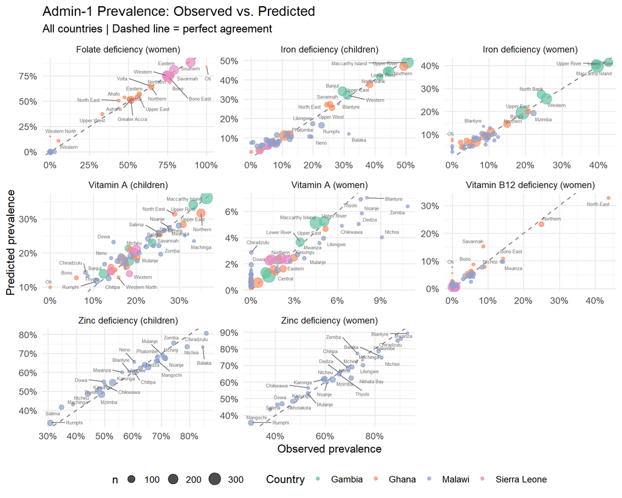

```r
if (!is.null(a1_all) && nrow(a1_all) > 0 &&
    "obs_prevalence" %in% colnames(a1_all)) {
  a1_plot <- a1_all |> filter(!is.na(Admin1), !is.na(obs_prevalence))

  if (nrow(a1_plot) > 0) {
    p <- ggplot(a1_plot, aes(x = obs_prevalence, y = pred_prevalence)) +
      geom_abline(slope = 1, intercept = 0, linetype = "dashed", colour = "grey50") +
      geom_point(aes(size = n, colour = country), alpha = 0.7) +
      ggrepel::geom_text_repel(aes(label = Admin1), size = 2,
                                max.overlaps = 15, colour = "grey40") +
      scale_x_continuous(labels = percent_format(accuracy = 1)) +
      scale_y_continuous(labels = percent_format(accuracy = 1)) +
      scale_size_area(name = "n", max_size = 7) +
      scale_colour_brewer(name = "Country", palette = "Set2") +
      facet_wrap(~ label, scales = "free") +
      labs(
        x = "Observed prevalence", y = "Predicted prevalence",
        title = "Admin-1 Prevalence: Observed vs. Predicted",
        subtitle = "All countries | Dashed line = perfect agreement"
      ) +
      theme(legend.position = "bottom")
    save_fig("admin1_obs_vs_pred", p)
    print(p)
  }
}
```

## 6.3 Admin-1 prevalence maps

Maps are pre-rendered by `scripts/render_maps.R` with a single shared colour scale per outcome across all countries. Run `Rscript scripts/render_maps.R` to regenerate.

```r
# Include pre-rendered Admin-1 map PNGs
a1_pngs <- list.files(here("results", "figures"),
                        pattern = "^admin1_maps_.*\\.png$", full.names = TRUE)
if (length(a1_pngs) > 0) {
  for (f in sort(a1_pngs)) {
    oc_tag <- sub("admin1_maps_(.*)\\.png", "\\1", basename(f))
    oc_label <- outcome_labels[oc_tag]
    if (is.na(oc_label)) oc_label <- oc_tag
    cat(sprintf("\n\n### %s\n\n", oc_label))
    cat(sprintf("![Admin-1 prevalence: %s](%s){width=100%%}\n\n", oc_label, f))
  }
} else {
  cat("Pre-rendered Admin-1 maps not found. Run `Rscript scripts/render_maps.R`.\n")
}
```

### 6.3.1 Iron deficiency (children)

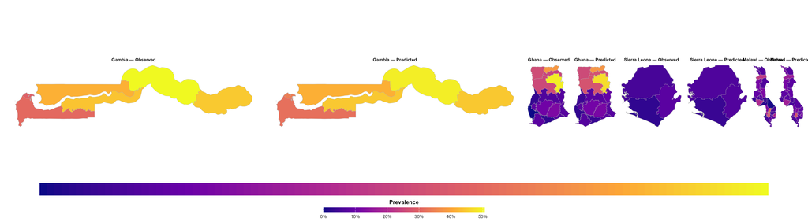

Admin-1 prevalence: Iron deficiency (children)

### 6.3.2 Vitamin A (children)

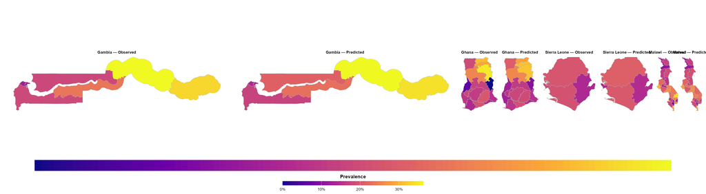

Admin-1 prevalence: Vitamin A (children)

### 6.3.3 Zinc deficiency (children)

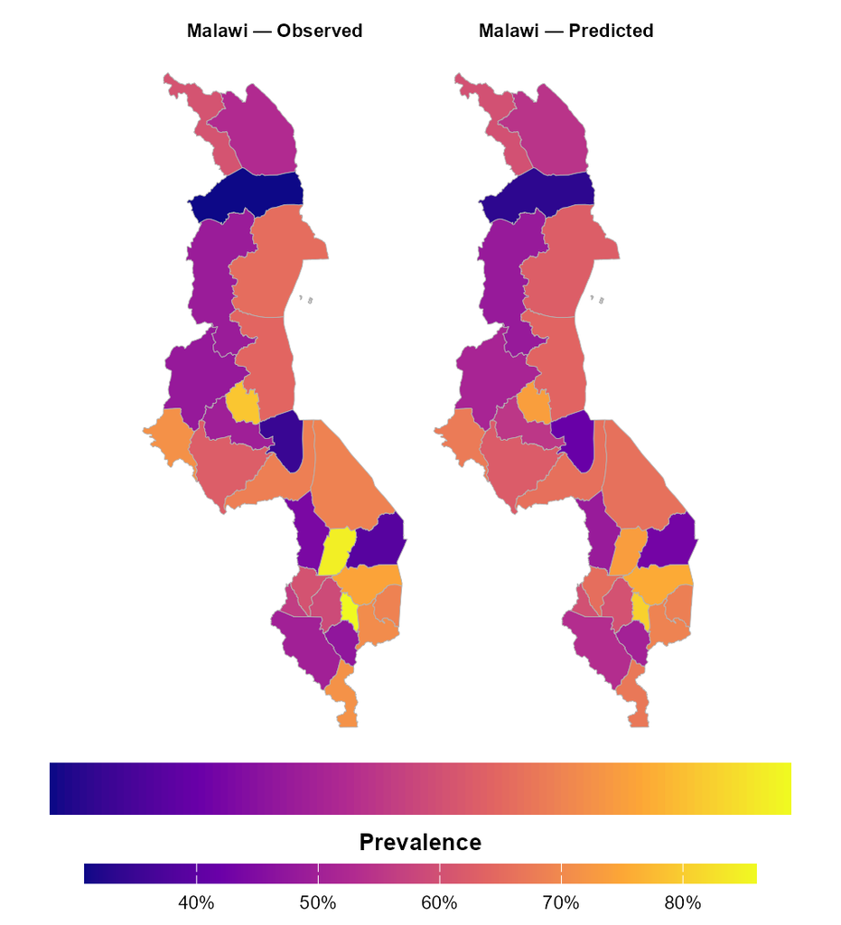

Admin-1 prevalence: Zinc deficiency (children)

### 6.3.4 Vitamin B12 deficiency (women)

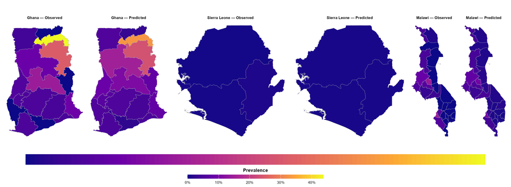

Admin-1 prevalence: Vitamin B12 deficiency (women)

### 6.3.5 Folate deficiency (women)

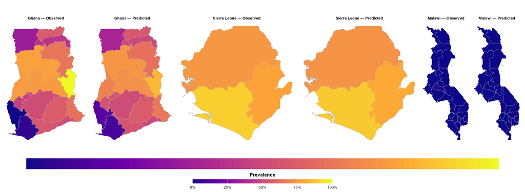

Admin-1 prevalence: Folate deficiency (women)

### 6.3.6 Iron deficiency (women)

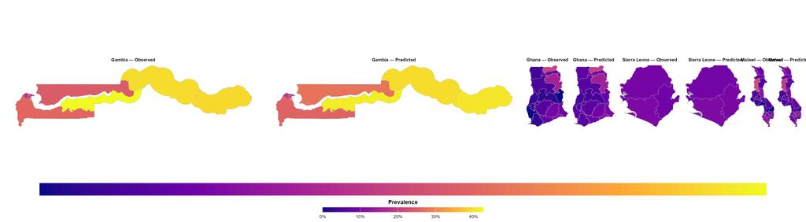

Admin-1 prevalence: Iron deficiency (women)

### 6.3.7 Vitamin A (women)

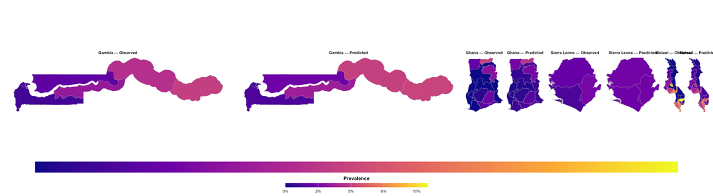

Admin-1 prevalence: Vitamin A (women)

### 6.3.8 Zinc deficiency (women)

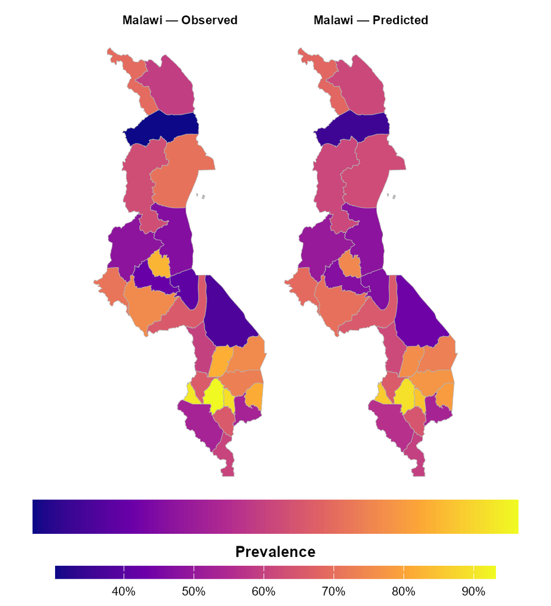

Admin-1 prevalence: Zinc deficiency (women)

Each panel pair shows observed (survey) and predicted (SL) prevalence for one country, using a single shared colour scale per outcome across all countries for direct comparison.

## 6.4 Conformal prediction interval width maps

```r
# Include pre-rendered CI width map PNGs
ci_pngs <- list.files(here("results", "figures"),
                       pattern = "^admin1_ci_width_.*\\.png$", full.names = TRUE)
if (length(ci_pngs) > 0) {
  for (f in sort(ci_pngs)) {
    oc_tag <- sub("admin1_ci_width_(.*)\\.png", "\\1", basename(f))
    oc_label <- outcome_labels[oc_tag]
    if (is.na(oc_label)) oc_label <- oc_tag
    cat(sprintf("\n\n### %s\n\n", oc_label))
    cat(sprintf("![CI width: %s](%s){width=100%%}\n\n", oc_label, f))
  }
} else {
  cat("Pre-rendered CI width maps not found. Run `Rscript scripts/render_maps.R`.\n")
}
```

### 6.4.1 Iron deficiency (children)

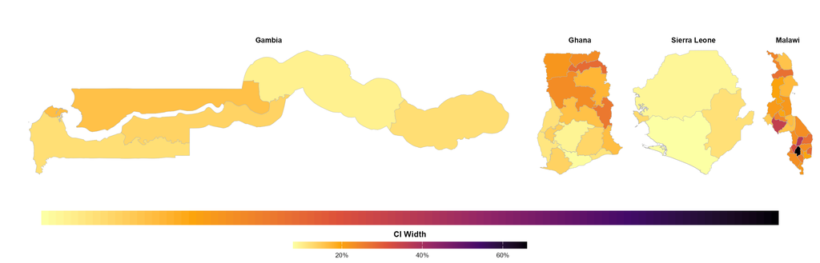

CI width: Iron deficiency (children)

### 6.4.2 Vitamin A (children)

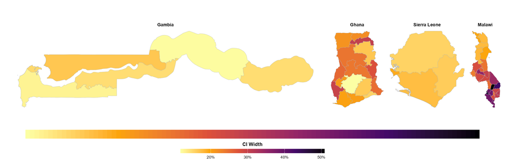

CI width: Vitamin A (children)

### 6.4.3 Zinc deficiency (children)

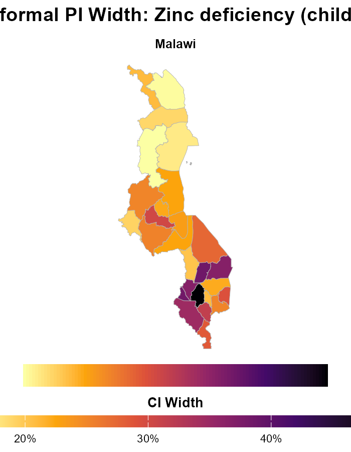

CI width: Zinc deficiency (children)

### 6.4.4 Vitamin B12 deficiency (women)

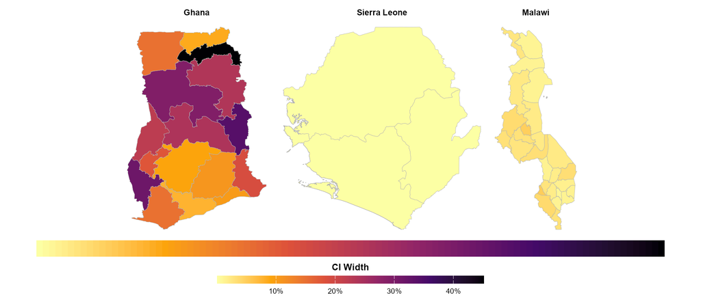

CI width: Vitamin B12 deficiency (women)

### 6.4.5 Folate deficiency (women)

[figure not shown]

CI width: Folate deficiency (women)

### 6.4.6 Iron deficiency (women)

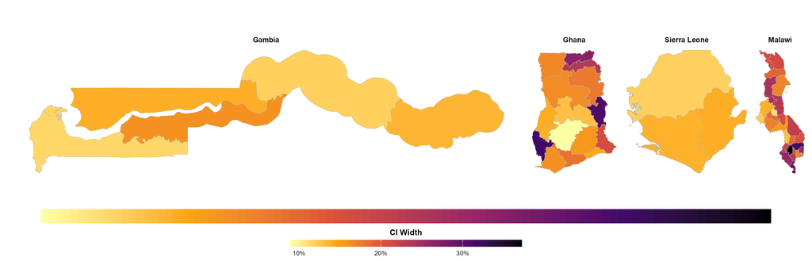

CI width: Iron deficiency (women)

### 6.4.7 Vitamin A (women)

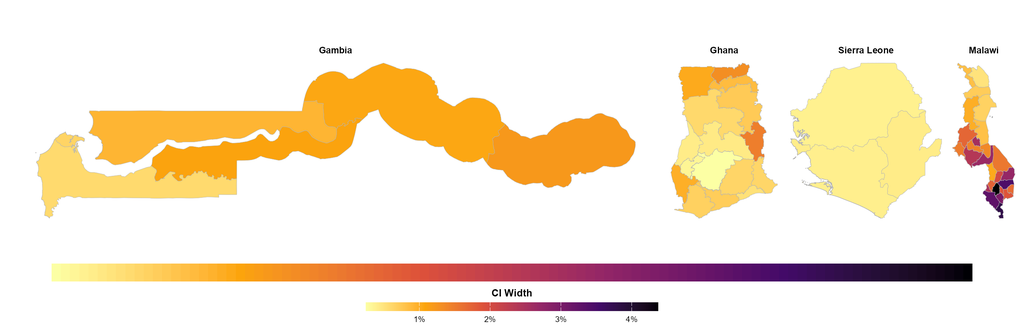

CI width: Vitamin A (women)

### 6.4.8 Zinc deficiency (women)

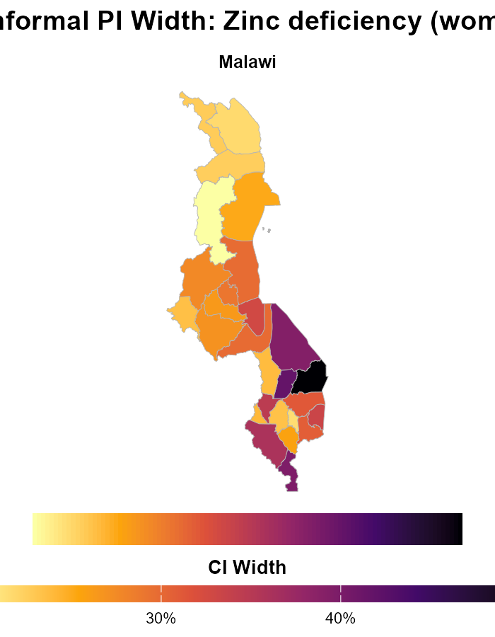

CI width: Zinc deficiency (women)

Wider intervals indicate greater uncertainty — these are priority areas for additional data collection. Conformal prediction intervals provide finite-sample marginal coverage guarantees (nominally 95%) without distributional assumptions.